## Analysis of the wearable activity data

Jerry Peng, 6-19-2014

### Introduction

The activity monitoring devices such as [Fitbit](http://www.fitbit.com), [Nike Fuelband](http://www.nike.com/us/en_us/c/nikeplus-fuelband), or [Jawbone Up](https://jawbone.com/up) are gaining popularity. With these gadgets, people can monitor their activities, “quantify” their movement, and find patterns of their behaviors, with the hope of improving their health.

In this report we analysed the data collected from personal activity monitoring devices, and studied the patterns of daily activities. The data, collected from an anonymous individual, includes step numbers taken in 5 minute interval each day in 2 months from October to November 2012. We found that there is a significant difference in activity patterns between weekdays and weekends.

### Loading and preprocessing the data

The data can be downloaded from [here](https://d396qusza40orc.cloudfront.net/repdata%2Fdata%2Factivity.zip) [52K].

```r
raw_data <- read.csv("activity.csv")
str(raw_data)
```

```
## 'data.frame':    17568 obs. of  3 variables:
##  $ steps   : int  NA NA NA NA NA NA NA NA NA NA ...
##  $ date    : Factor w/ 61 levels "2012-10-01","2012-10-02",..: 1 1 1 1 1 1 1 1 1 1 ...
##  $ interval: int  0 5 10 15 20 25 30 35 40 45 ...
```

Note that there are 3 columns in the dataset: steps(int), date(factor), and interval(int). The data type of column “date”" needs to be converted to type of date:

```r
raw_data$date <- as.Date(raw_data$date)
```

There is a lot of missing data, which will be filled in with the averaged value in the same time interval later.

### What is mean total number of steps taken per day?

As a first step, a histogram of the total number of steps taken in each day is plotted:

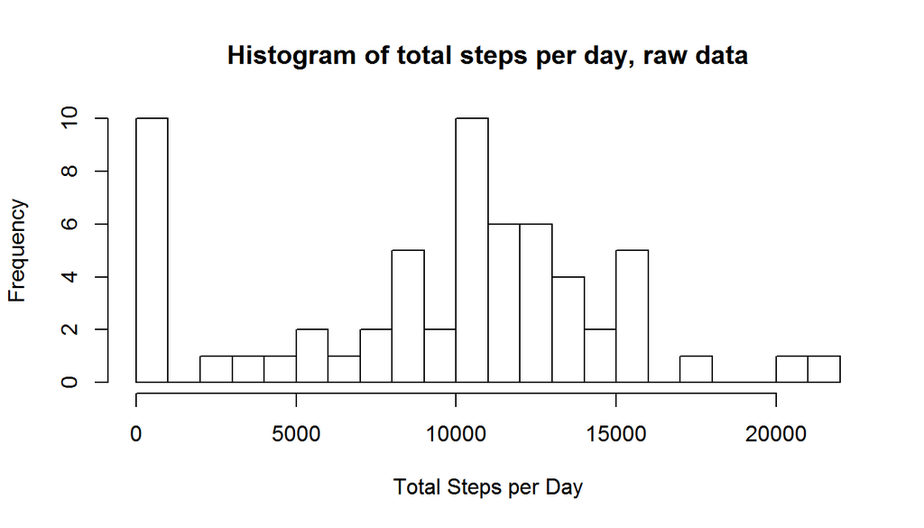

```r
tmp <- split(raw_data$steps,raw_data$date)
steps_each_day <- sapply(tmp,sum,na.rm=TRUE)
hist(steps_each_day, breaks=20, xlab="Total Steps per Day",
     main = "Histogram of total steps per day, raw data")
```

The average number of total steps taken per day is:

```r
mean(steps_each_day, na.rm=TRUE)
```

```
## [1] 9354
```

the median number of total steps taken per day is:

```r
median(steps_each_day, na.rm=TRUE)
```

```
## [1] 10395
```

### What is the average daily activity pattern?

To study the daily activity pattern, a time-series plot of the 5-minute interval (x-axis) and the average number of steps taken, averaged across all days (y-axis) is made:

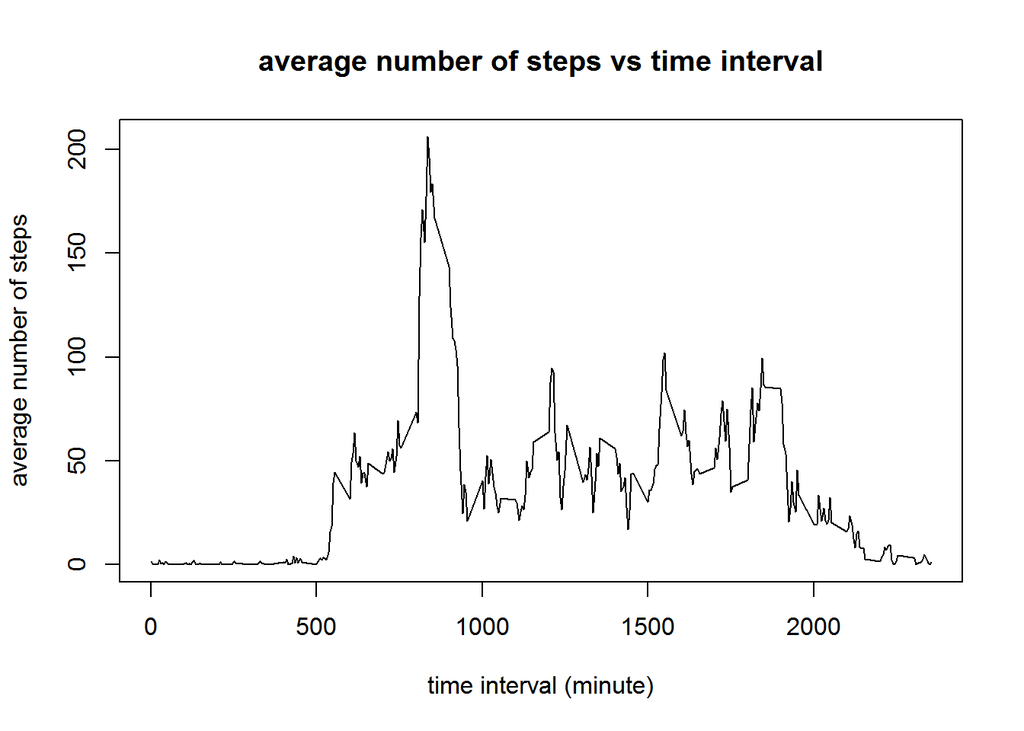

```r
tmp <- split(raw_data$steps,raw_data$interval)
average_steps_each_interval <- sapply(tmp,mean,na.rm=TRUE)
plot(as.numeric(names(tmp)),average_steps_each_interval, type="l",
     xlab="time interval (minute)", ylab="average number of steps")
title("average number of steps vs time interval")
```

The 5-minute interval, on average across all the days in the dataset, having the maximum number of steps is:

```r
names(which(average_steps_each_interval==max(average_steps_each_interval)))
```

```
## [1] "835"
```

```r
##in minute. average.steps.each.interval is a named vector
```

### Imputing missing values

The total number of missing values in the dataset is:

```r
sum(is.na(raw_data$steps))
```

```
## [1] 2304
```

The average value for the same 5-minute interval is used to fill in the missing values in the dataset:

```r
ind.Null <- which(is.na(raw_data$steps)) # index of NA rows
# corresponding interval values;converted to string
intervalVal <-  as.character(raw_data$interval[ind.Null])
new_data <- raw_data #create new dataset
new_data$steps[ind.Null]<-average_steps_each_interval[intervalVal] #fill in the average steps number
```

The new dataset(new_dat) is created with the missing values filled using the average step number of the same interval.

Now with the new dataset, a histogram of the total number of steps taken each day is plotted:

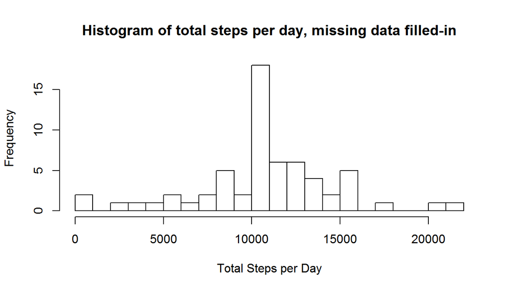

```r
tmp <- split(new_data$steps,new_data$date)
new_steps_each_day <- sapply(tmp,sum)
hist(new_steps_each_day, breaks=20, xlab="Total Steps per Day",
     main = "Histogram of total steps per day, missing data filled-in")
```

The average number of total steps taken per day is:

```r
mean(new_steps_each_day)
```

```
## [1] 10766
```

the median number of total steps taken per day is:

```r
median(new_steps_each_day)
```

```
## [1] 10766
```

These values are different from the estimates from the first part of the assignment. Imputing missing data reduces greatly the frequency of zero step per day, and makes the data less skewed.

### Are there differences in activity patterns between weekdays and weekends?

A new factor variable in the dataset with two levels - “weekday” and “weekend” indicating whether a given date is a weekday or weekend day is added to the new dataset:

```r
tmp <- factor(weekdays(new_data$date) %in% c('Saturday','Sunday'))
levels(tmp) = c('weekday','weekend')
new_data <- transform(new_data,weekday=tmp)
```

A panel plot containing a time series plot (i.e. type = “l”) of the 5-minute interval (x-axis) and the average number of steps taken, averaged across all weekday days or weekend days (y-axis) is made as follows:

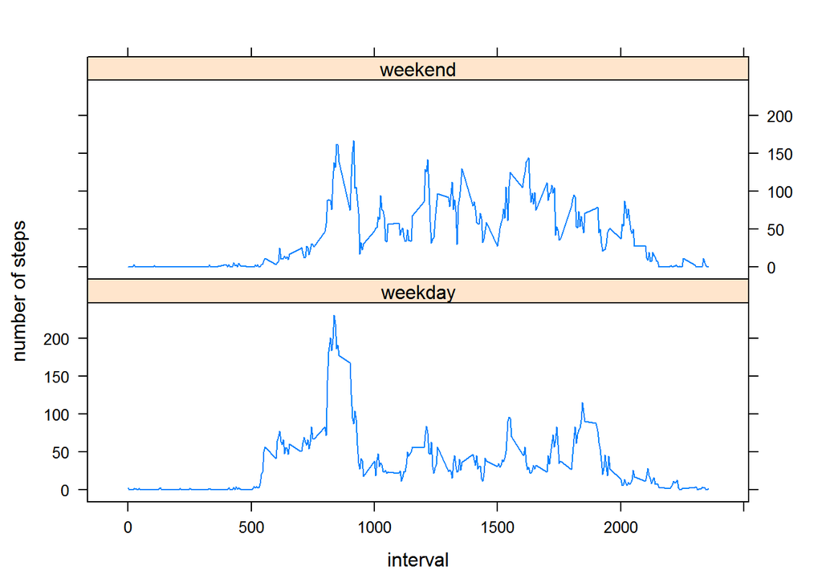

```r
library(plyr)
library(lattice)
new_average <- ddply(new_data,c("interval", "weekday"),
                               function(df) mean(df$steps))
xyplot(new_average$V1 ~ new_average$interval | new_average$weekday, type="l",
       layout=c(1,2),xlab="interval",ylab="number of steps")
```

The plots above show clearly different activity patterns between weekdays and weekends. On weekdays there are significantly more activities (more steps) in the first half of day (before interval of 1000), while on weekends relatively more balanced activities in the mid day between about interval 700 to 2100.